# Investment Analysis Project

- Assignee: Anna Benešová
- Date: 3.1.2025
- Subject: NMFP533

### Instructions

We were tasked with analyzing a set of NASDAQ stocks to construct a market portfolio across four main parts:

1. **Data Processing and Basic Exploration**
2. **Efficient Frontier, Capital Market Line (CML), and Security Market Line (SML)**
3. **Markowitz Model**
4. **Out-of-Sample Investment with Initial Capital of $100,000 USD**

The assigned stocks are provided in the table below together with brief information about sector and S&P 500 status.

| Ticker | Company | Included in S&P 500 | Sector |
| --- | --- | --- | --- |
| GOOGL | Alphabet | Yes | Communication Services |
| AMGN | Amgen | Yes | Health Care |
| AVGO | Broadcom | Yes | Information Technology |
| DLTR | Dollar Tree | Yes | Consumer Discretionary |
| ISRG | Intuitive Surgical | Yes | Health Care |
| LULU | Lululemon Athletica | Yes | Consumer Discretionary |
| QCOM | Qualcomm | Yes | Information Technology |
| TXN | Texas Instruments | Yes | Information Technology |

# 1. Data Processing and Basic Exploration

In this section, we will focus on data loading, essential preprocessing, and conducting basic exploratory analysis through plots and descriptive statistics.

## 1.1 Data Processing

### 1.1.1 Data Loading

For data acquisition, we utilized the *yfinance* library to retrieve historical stock prices spanning from January 1, 2021, to October 25, 2024. The data quality assessment revealed complete and consistent records with no anomalous values or irregularities. In accordance with the assignment requirements, we also obtained U.S. Treasury Bond data for the corresponding period, specifically selecting the one-month Treasury bill rate as our risk-free rate $r_f$.

Daily returns $Y_j$ of stock j were calculated using the logarithm of the ratio between closing ($X^c_j$) and opening prices ($X^o_j$):

$$ Y_j = \log\left(\frac{X^c_j}{X^o_j} \right) $$

The logarithmic returns were chosen over simple returns for several key advantages:

1. They are additive over time, making them more suitable for time series analysis
2. They typically exhibit better statistical properties, including closer approximation to normal distribution
3. They prevent stock prices from becoming negative in theoretical models
4. They provide better handling of compounding effects

The annual risk-free rate ($r^{annual}_f$) was converted to a daily rate ($r_f$) using:

$$ r_f = \frac{\log(1 + \frac{r^{annual}_f}{100})}{252} $$

This logarithmic transformation is preferred over simple division by 252 trading days because it accounts for continuous compounding and maintains consistency with our logarithmic returns framework, ensuring more accurate risk-adjusted performance metrics.

### 1.1.2 Data Validation and Structure

We implemented two complementary data structures for our analysis:

1. An aggregated DataFrame of daily returns for all stocks, enabling efficient portfolio-level calculations and cross-sectional analysis
2. A dictionary with stock tickers as keys, facilitating individual stock analysis and maintaining data organization

During the validation process, we identified several dates where certain stocks had missing or inconsistent data. Using a custom validation function, we detected few dates with discrepancies. To maintain data integrity and prevent bias in our analysis, these dates were excluded from the dataset. The specific dates and affected stocks are detailed below:

```
Missing Dates in Risk-Free Rate Data:
+------------+
|    Date    |
+------------+
| 2021-10-11 |
| 2021-11-11 |
| 2022-10-10 |
| 2022-11-11 |
| 2023-10-09 |
| 2024-10-14 |
+------------+

Missing Dates in Combo Rate Data:
+------------+
|    Date    |
+------------+
| 2021-04-02 |
| 2023-04-07 |
+------------+
```

## 1.2 Data Exploration

### 1.2.1 Desctiptive Statistics

First, we showcase an overview of common descriptive statistics of combined returns $Y$ and $r_f$. Notice all have the same count (954) indicating correct data loading and alignment across the assets.

The expected returns show the average daily returns for the assets. **GOOGL** ($\mu_{GOOGL}=0.00061$) and AVGO ($\mu_{AVGO}=0.00041$) exhibit positive expected returns, indicating slight daily growth, while other assets like **AMGN** ($\mu_{AMGN}=-0.00012$) and LULU ($\mu_{LULU}=-0.00067$) show negative expected returns, suggesting slight daily losses.

The distribution of returns appears slightly asymmetric, as evidenced by the differences between mean ($\mu$) and median ($m$) values across assets, suggesting potential skewness in daily returns that could be relevant for risk management considerations.

```
Daily Returns Summary:
+-------+---------+---------+---------+---------+---------+---------+---------+---------+
|       |   GOOGL |    AMGN |    AVGO |    DLTR |    ISRG |    LULU |    QCOM |     TXN |
|-------+---------+---------+---------+---------+---------+---------+---------+---------|
| count | 954     | 954     | 954     | 954     | 954     | 954     | 954     | 954     |
| mean  |   0.001 |  -0     |   0     |  -0     |   0     |  -0.001 |  -0     |  -0     |
| std   |   0.015 |   0.012 |   0.019 |   0.017 |   0.017 |   0.019 |   0.019 |   0.014 |
| min   |  -0.054 |  -0.064 |  -0.084 |  -0.136 |  -0.086 |  -0.083 |  -0.078 |  -0.054 |
| 25%   |  -0.008 |  -0.007 |  -0.011 |  -0.009 |  -0.008 |  -0.012 |  -0.011 |  -0.009 |
| 50%   |   0.001 |  -0     |   0.001 |  -0     |   0.001 |  -0     |   0.001 |   0     |
| 75%   |   0.01  |   0.007 |   0.012 |   0.01  |   0.01  |   0.01  |   0.011 |   0.009 |
| max   |   0.063 |   0.036 |   0.092 |   0.083 |   0.08  |   0.083 |   0.078 |   0.057 |
+-------+---------+---------+---------+---------+---------+---------+---------+---------+

Risk-Free Rate Summary:
+-------+---------+------------------------+
|       |    1 Mo |   Daily_Risk_Free_Rate |
|-------+---------+------------------------|
| count | 954     |                    954 |
| mean  |   2.956 |                      0 |
| std   |   2.414 |                      0 |
| min   |   0     |                      0 |
| 25%   |   0.06  |                      0 |
| 50%   |   3.835 |                      0 |
| 75%   |   5.48  |                      0 |
| max   |   6.02  |                      0 |
+-------+---------+------------------------+
```

```
Expected Returns (Mean) (10^(-3)):
+----+----------+--------------------+
|    | Ticker   |   Expected Returns |
|----+----------+--------------------|
|  0 | GOOGL    |              0.614 |
|  1 | AMGN     |             -0.123 |
|  2 | AVGO     |              0.411 |
|  3 | DLTR     |             -0.019 |
|  4 | ISRG     |              0.066 |
|  5 | LULU     |             -0.671 |
|  6 | QCOM     |             -0.21  |
|  7 | TXN      |             -0.044 |
+----+----------+--------------------+

Covariance Matrix (10^(-3)):
+-------+---------+--------+--------+--------+--------+--------+--------+-------+
|       |   GOOGL |   AMGN |   AVGO |   DLTR |   ISRG |   LULU |   QCOM |   TXN |
|-------+---------+--------+--------+--------+--------+--------+--------+-------|
| GOOGL |   0.219 |  0.03  |  0.141 |  0.048 |  0.12  |  0.128 |  0.149 | 0.105 |
| AMGN  |   0.03  |  0.135 |  0.04  |  0.044 |  0.045 |  0.032 |  0.037 | 0.044 |
| AVGO  |   0.141 |  0.04  |  0.362 |  0.066 |  0.142 |  0.16  |  0.246 | 0.173 |
| DLTR  |   0.048 |  0.044 |  0.066 |  0.296 |  0.058 |  0.094 |  0.069 | 0.056 |
| ISRG  |   0.12  |  0.045 |  0.142 |  0.058 |  0.273 |  0.141 |  0.148 | 0.1   |
| LULU  |   0.128 |  0.032 |  0.16  |  0.094 |  0.141 |  0.352 |  0.164 | 0.124 |
| QCOM  |   0.149 |  0.037 |  0.246 |  0.069 |  0.148 |  0.164 |  0.356 | 0.188 |
| TXN   |   0.105 |  0.044 |  0.173 |  0.056 |  0.1   |  0.124 |  0.188 | 0.202 |
+-------+---------+--------+--------+--------+--------+--------+--------+-------+

Auto-covariances (Autocorrelations) (10^(-3)):
+----+----------+--------------------+
|    | Ticker   |   Autocorrelations |
|----+----------+--------------------|
|  0 | GOOGL    |             10.3   |
|  1 | AMGN     |             18.81  |
|  2 | AVGO     |            -20.768 |
|  3 | DLTR     |            -48.636 |
|  4 | ISRG     |            -18.581 |
|  5 | LULU     |             15.702 |
|  6 | QCOM     |            -47.494 |
|  7 | TXN      |            -89.045 |
+----+----------+--------------------+
```

### 1.2.2 Visualization

Daily returns visualization reveals distinct volatility patterns across our stock portfolio. **GOOGL** exhibits clear heteroskedasticity with volatility clustering in 2022, accompanied by mild return autocorrelation during this highly volatile period. In contrast, **AMGN** demonstrates more homoskedastic behavior, interrupted only by notable negative spikes in Q1 2024.

**AVGO** and **ISRG** share similar patterns but with different timing of volatile periods - **AVGO** showing increased volatility in 2024 with positive directional bias, while **ISRG** experienced heightened volatility in Q1 2022 during healthcare sector uncertainty (COVID). **DLTR** stands out with remarkably low baseline volatility, broken by extreme bidirectional spikes in Q3 2024.

**LULU** mirrors **ISRG's** pattern but with more pronounced negative spikes, while **QCOM** and **TXN** display relatively stable patterns with **QCOM** showing increased volatility in late 2024 and **TXN** exhibiting more pronounced movements early in the sample period.

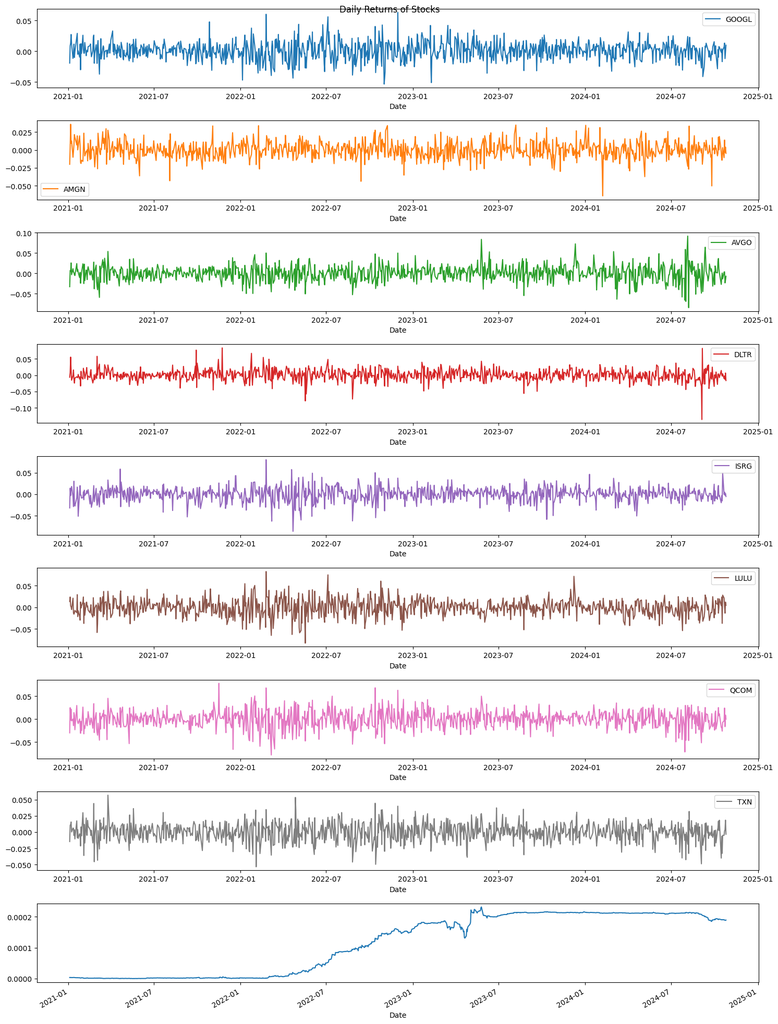

In the following script, we used the dictionary dataframe to iteratively explore each stock. The summary statistics include following metrics:

- `Open`: Day's first trade price
- `Close`: Final trading price
- `High/Low`: Price extremes during session
- `Volume`: Number of shares traded
- `Dividends`: Cash distributions to shareholders
- `Stock Splits`: Share quantity adjustments
- `Daily Returns`: Log returns of the ratio of `Close` and `Open`

Distribution analysis reveals some leptokurtic tendencies across all stocks, with **DLTR** exhibiting the highest kurtosis.

Price history analysis:

```
=== Data Exploration ===

Analysis for GOOGL:
--------------------------------------------------

Summary Statistics (scaled by 1000 and rounded to 3):
+-------+----------+----------+----------+----------+
|       |     Open |     High |      Low |    Close |
|-------+----------+----------+----------+----------|
| count | 960000   | 960000   | 960000   | 960000   |
| mean  | 127637   | 129078   | 126289   | 127702   |
| std   |  23800.3 |  23829.2 |  23666.9 |  23733.8 |
| min   |  84705.9 |  86207.5 |  83039   |  83128.7 |
| 25%   | 107632   | 109976   | 106449   | 108266   |
| 50%   | 128738   | 130148   | 127083   | 128576   |
| 75%   | 142268   | 143319   | 140442   | 141893   |
| max   | 189840   | 191277   | 188563   | 190708   |
+-------+----------+----------+----------+----------+

Key Metrics:
Total Trading Days: 960
Average Daily Volume: 31,409,308
Average Daily Return: 0.0629%
Return Volatility: 1.4763%
Maximum Daily Gain: 6.3041%
Maximum Daily Loss: -5.3584%
```

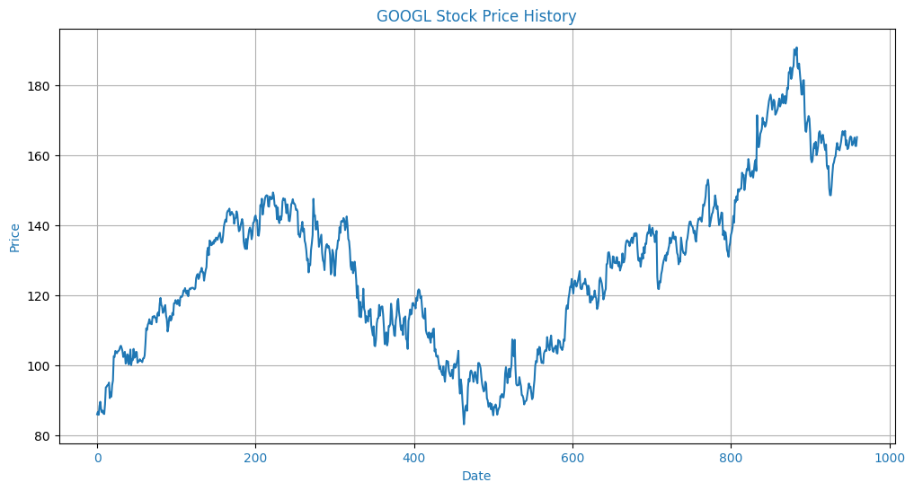

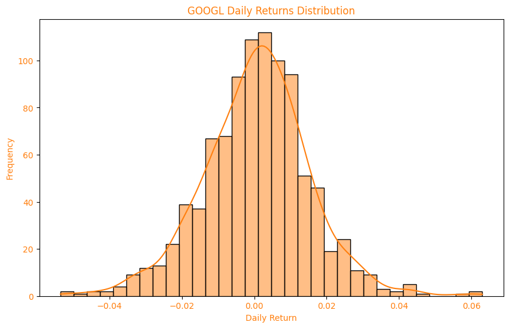

```
Analysis for AMGN:
--------------------------------------------------

Summary Statistics (scaled by 1000 and rounded to 3):
+-------+----------+----------+----------+----------+
|       |     Open |     High |      Low |    Close |
|-------+----------+----------+----------+----------|
| count | 960000   | 960000   | 960000   | 960000   |
| mean  | 241043   | 243268   | 238679   | 241004   |
| std   |  38194.7 |  38543.9 |  37757.4 |  38172.3 |
| min   | 182286   | 184705   | 180649   | 180867   |
| 25%   | 213825   | 215737   | 211338   | 213551   |
| 50%   | 227411   | 229078   | 225413   | 227491   |
| 75%   | 264308   | 267136   | 261789   | 264137   |
| max   | 336311   | 341719   | 331955   | 334703   |
+-------+----------+----------+----------+----------+

Key Metrics:
Total Trading Days: 960
Average Daily Volume: 2,641,295
Average Daily Return: -0.0156%
Return Volatility: 1.1588%
Maximum Daily Gain: 3.6010%
Maximum Daily Loss: -6.4270%
```

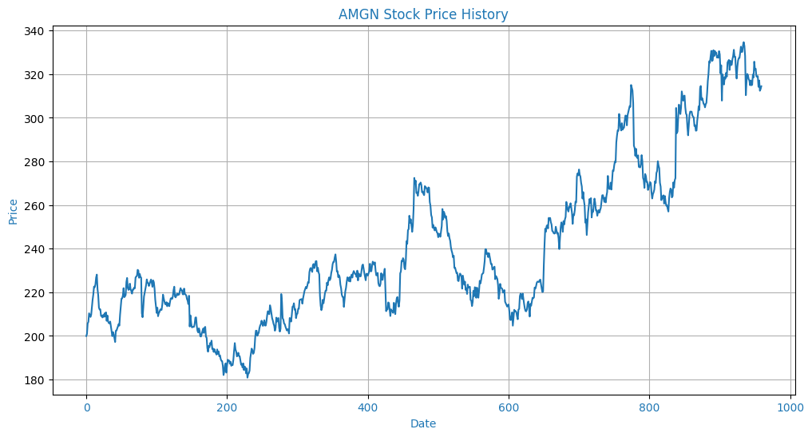

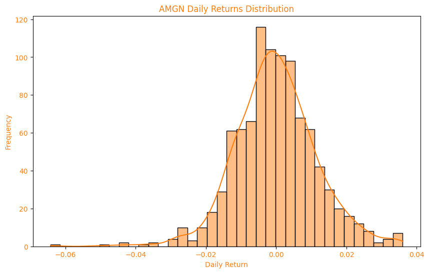

```
Analysis for AVGO:
--------------------------------------------------

Summary Statistics (scaled by 1000 and rounded to 3):
+-------+----------+----------+----------+----------+
|       |     Open |     High |      Low |    Close |
|-------+----------+----------+----------+----------|
| count | 960000   | 960000   | 960000   | 960000   |
| mean  |  76216.2 |  77296.9 |  75101.7 |  76238.1 |
| std   |  39647.3 |  40359.8 |  38828.1 |  39596.4 |
| min   |  38424.5 |  38977.3 |  38057.8 |  38238.4 |
| 25%   |  46546.4 |  46947.1 |  46123.3 |  46725.2 |
| 50%   |  56448.6 |  57002.3 |  55608.1 |  56420.7 |
| 75%   |  89558.9 |  90810.4 |  88809.2 |  89942.9 |
| max   | 183069   | 185922   | 182042   | 185453   |
+-------+----------+----------+----------+----------+

Key Metrics:
Total Trading Days: 960
Average Daily Volume: 24,638,355
Average Daily Return: 0.0404%
Return Volatility: 1.9076%
Maximum Daily Gain: 9.1860%
Maximum Daily Loss: -8.4262%
```

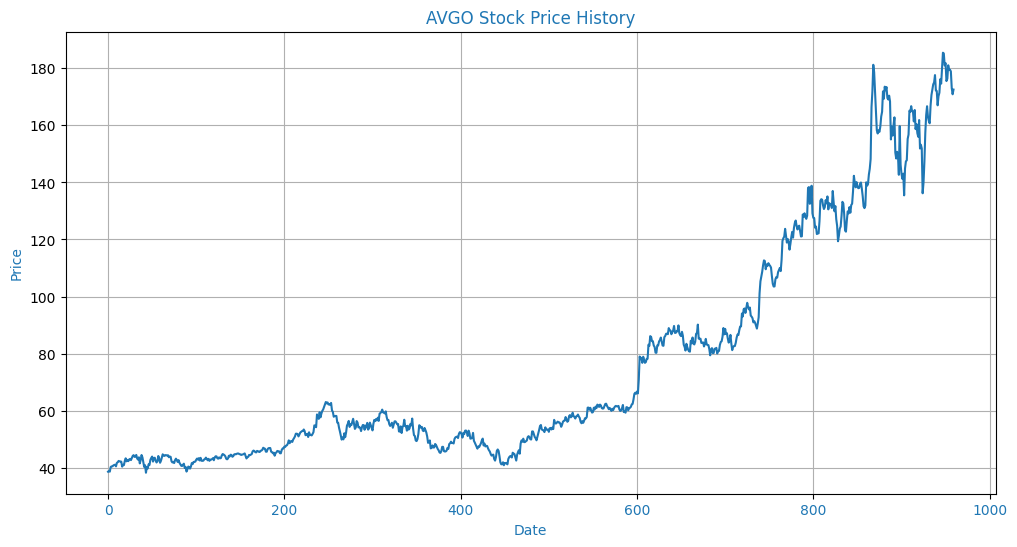

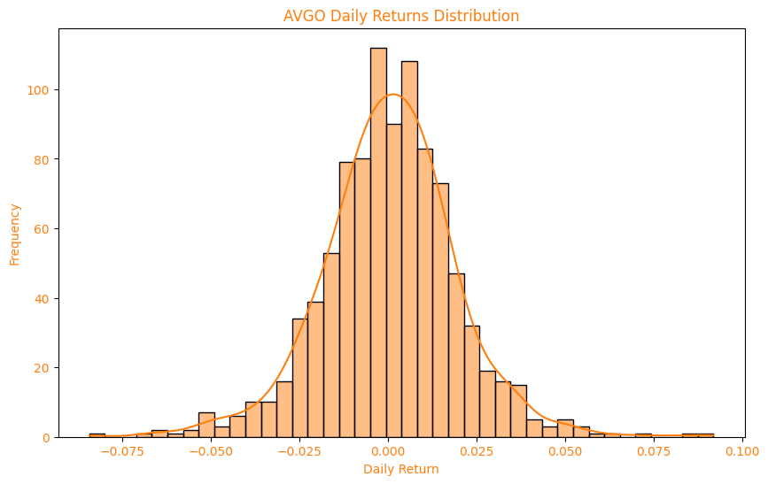

```
Analysis for DLTR:
--------------------------------------------------

Summary Statistics (scaled by 1000 and rounded to 3):
+-------+----------+----------+----------+----------+
|       |     Open |     High |      Low |    Close |
|-------+----------+----------+----------+----------|
| count | 960000   | 960000   | 960000   | 960000   |
| mean  | 127314   | 128909   | 125737   | 127338   |
| std   |  24552.1 |  24883.1 |  24287.3 |  24673.6 |
| min   |  63090   |  66990   |  60820   |  63560   |
| 25%   | 107288   | 108625   | 106122   | 107443   |
| 50%   | 131860   | 133650   | 129535   | 132190   |
| 75%   | 146295   | 148430   | 144610   | 146612   |
| max   | 175120   | 177190   | 172650   | 174080   |
+-------+----------+----------+----------+----------+

Key Metrics:
Total Trading Days: 960
Average Daily Volume: 2,659,294
Average Daily Return: -0.0027%
Return Volatility: 1.7183%
Maximum Daily Gain: 8.3331%
Maximum Daily Loss: -13.5594%
```

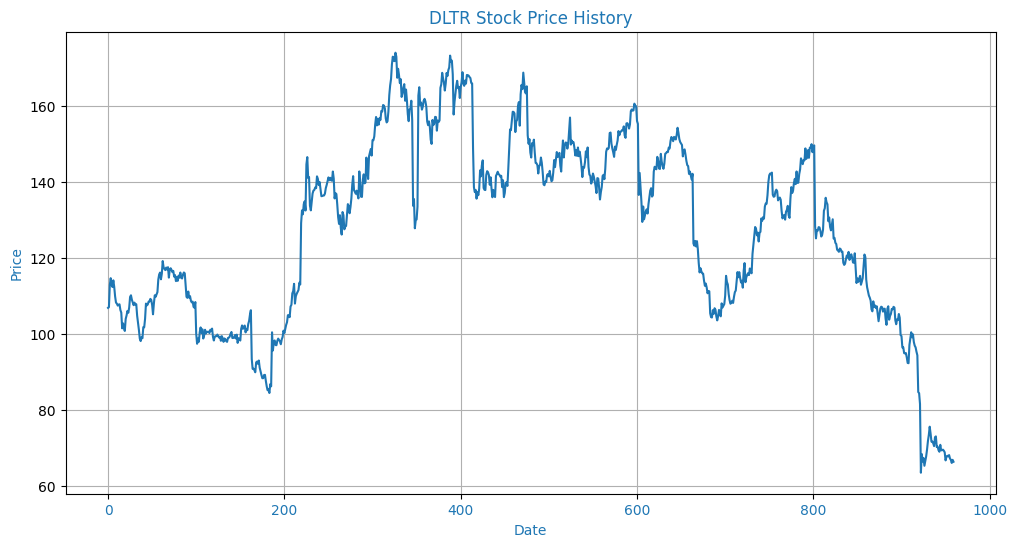

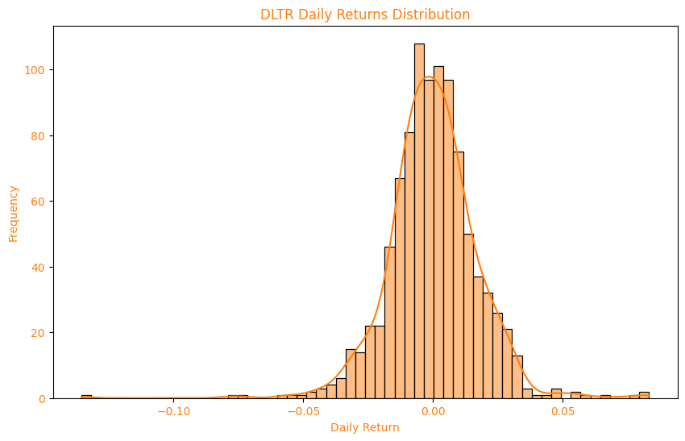

```
Analysis for ISRG:
--------------------------------------------------

Summary Statistics (scaled by 1000 and rounded to 3):
+-------+----------+----------+----------+---------+
|       |     Open |     High |      Low |   Close |
|-------+----------+----------+----------+---------|
| count | 960000   | 960000   | 960000   |  960000 |
| mean  | 310475   | 314038   | 306676   |  310495 |
| std   |  73798.5 |  74022.3 |  73299.5 |   73795 |
| min   | 181110   | 186970   | 180070   |  183060 |
| 25%   | 257625   | 259780   | 253996   |  256930 |
| 50%   | 299035   | 303090   | 295135   |  299165 |
| 75%   | 349530   | 353928   | 346363   |  348918 |
| max   | 519040   | 523340   | 514550   |  521150 |
+-------+----------+----------+----------+---------+

Key Metrics:
Total Trading Days: 960
Average Daily Volume: 1,744,811
Average Daily Return: 0.0066%
Return Volatility: 1.6523%
Maximum Daily Gain: 7.9956%
Maximum Daily Loss: -8.5994%
```

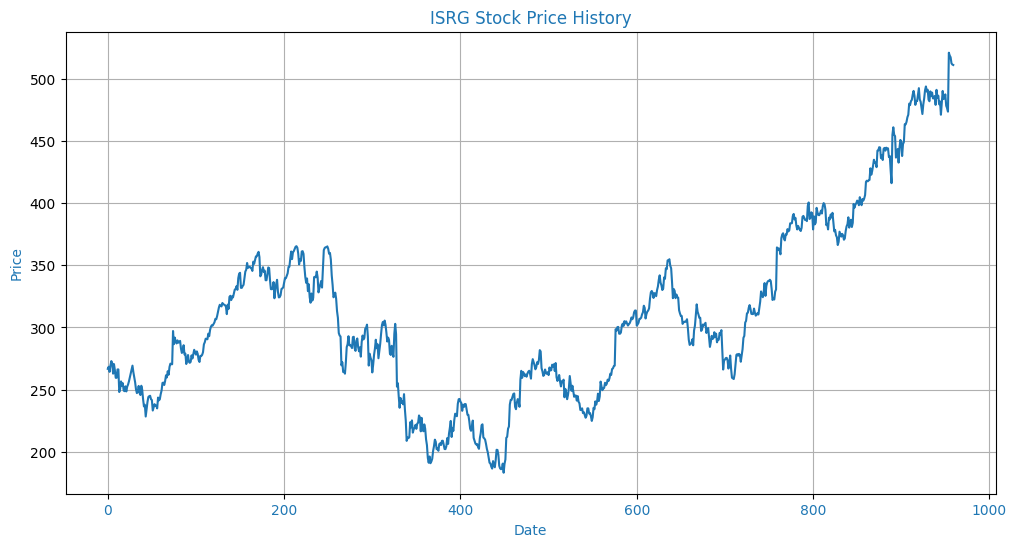

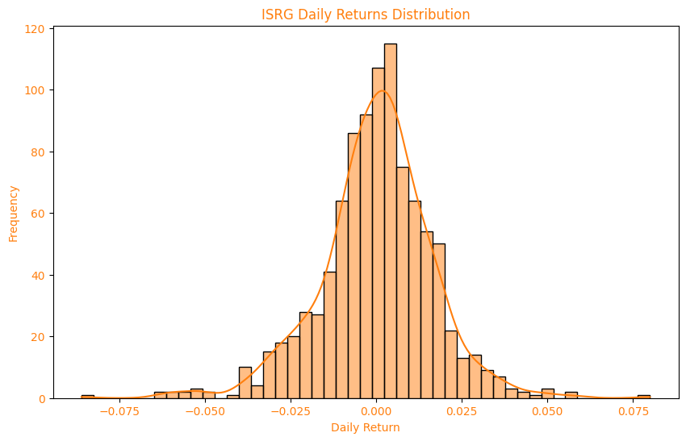

```
Analysis for LULU:
--------------------------------------------------

Summary Statistics (scaled by 1000 and rounded to 3):
+-------+----------+----------+----------+----------+
|       |     Open |     High |      Low |    Close |
|-------+----------+----------+----------+----------|
| count | 960000   | 960000   | 960000   | 960000   |
| mean  | 353972   | 358551   | 348914   | 353735   |
| std   |  59005.8 |  58992.2 |  58937.1 |  59011.2 |
| min   | 228080   | 236350   | 226010   | 233400   |
| 25%   | 309145   | 314150   | 304695   | 309460   |
| 50%   | 346495   | 351180   | 340680   | 346130   |
| 75%   | 387455   | 392052   | 383395   | 386220   |
| max   | 513240   | 516390   | 508460   | 511290   |
+-------+----------+----------+----------+----------+

Key Metrics:
Total Trading Days: 960
Average Daily Volume: 1,610,777
Average Daily Return: -0.0685%
Return Volatility: 1.8807%
Maximum Daily Gain: 8.2511%
Maximum Daily Loss: -8.2647%
```

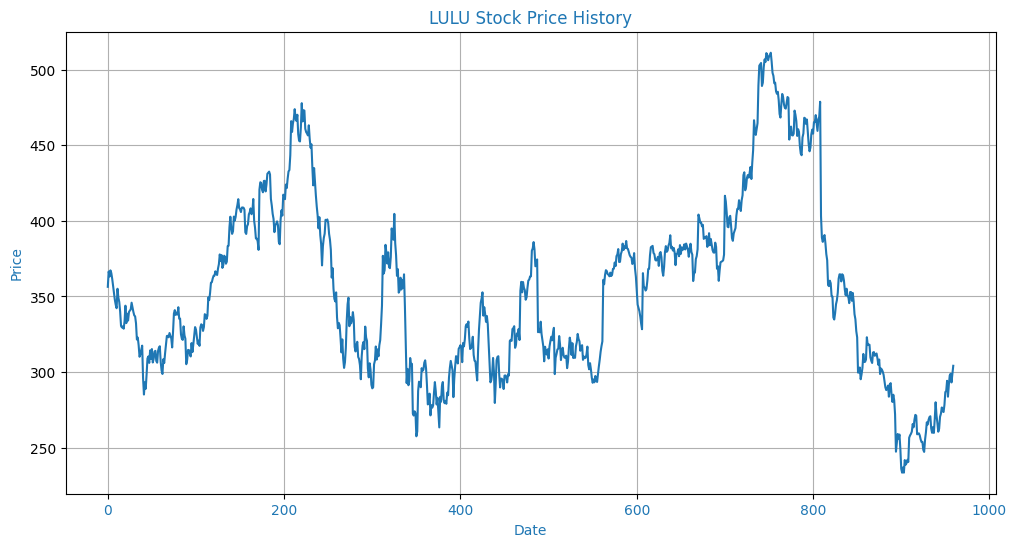

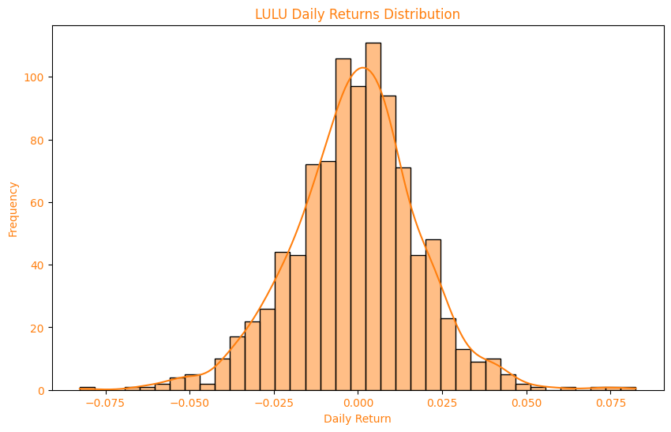

```
Analysis for QCOM:
--------------------------------------------------

Summary Statistics (scaled by 1000 and rounded to 3):
+-------+----------+----------+----------+----------+
|       |     Open |     High |      Low |    Close |
|-------+----------+----------+----------+----------|
| count | 960000   | 960000   | 960000   | 960000   |
| mean  | 136804   | 138676   | 134800   | 136768   |
| std   |  25468.5 |  25851.4 |  24933.8 |  25386.5 |
| min   |  97948.5 |  99111.3 |  96737   |  98587.7 |
| 25%   | 118164   | 119635   | 116776   | 118126   |
| 50%   | 128854   | 131097   | 127202   | 128932   |
| 75%   | 154457   | 157091   | 151385   | 154242   |
| max   | 224480   | 228250   | 223668   | 224747   |
+-------+----------+----------+----------+----------+

Key Metrics:
Total Trading Days: 960
Average Daily Volume: 8,935,727
Average Daily Return: -0.0179%
Return Volatility: 1.8944%
Maximum Daily Gain: 7.8344%
Maximum Daily Loss: -7.8268%
```

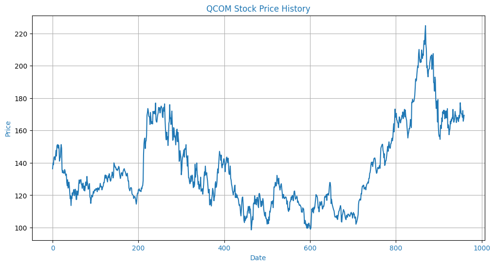

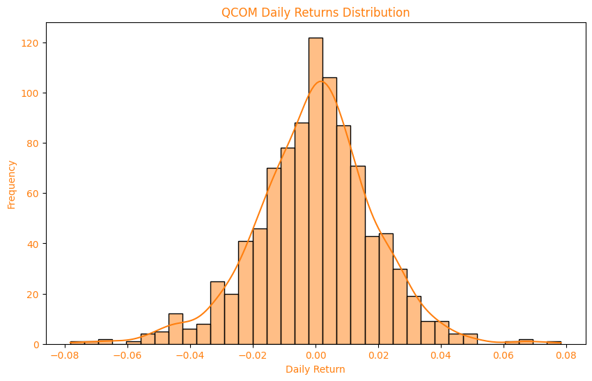

```
Analysis for TXN:
--------------------------------------------------

Summary Statistics (scaled by 1000 and rounded to 3):
+-------+----------+--------+----------+----------+
|       |     Open |   High |      Low |    Close |
|-------+----------+--------+----------+----------|
| count | 960000   | 960000 | 960000   | 960000   |
| mean  | 167156   | 168889 | 165267   | 167147   |
| std   |  14698.3 |  14682 |  14549.2 |  14625.3 |
| min   | 135403   | 137493 | 134223   | 136608   |
| 25%   | 157251   | 158991 | 155490   | 157209   |
| 50%   | 165864   | 167594 | 163780   | 165826   |
| 75%   | 172836   | 174395 | 171357   | 172929   |
| max   | 211190   | 213256 | 210017   | 212938   |
+-------+----------+--------+----------+----------+

Key Metrics:
Total Trading Days: 960
Average Daily Volume: 5,183,384
Average Daily Return: -0.0026%
Return Volatility: 1.4219%
Maximum Daily Gain: 5.7071%
Maximum Daily Loss: -5.3501%
```

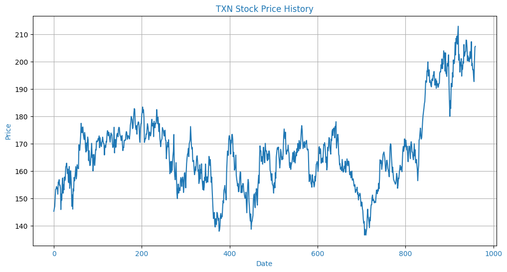

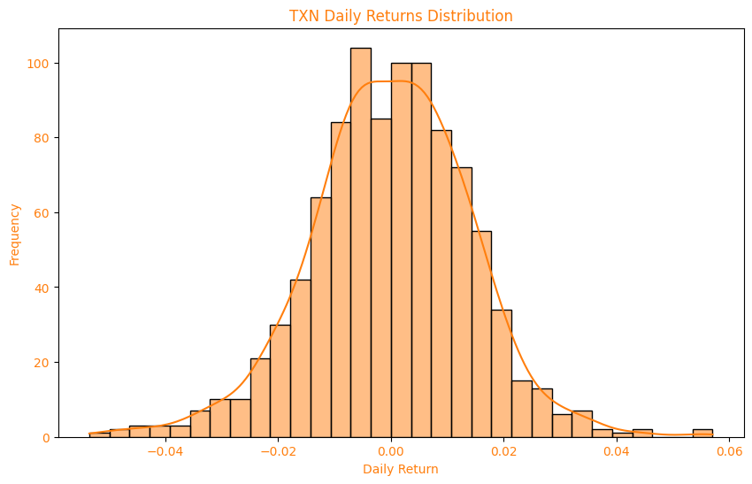

We also deployed script for combined plots that revelead some interesting insights.

In case of price movements in the first figure, **LULU** and **ISRG** show correlated movements until Q2 2023, when **ISRG** broke away with stronger upward momentum, likely due to healthcare sector recovery. Furthemore, a group of four stocks (**GOOGL**, **AVGO**, **QCOM**, **TXN**) demonstrate similar price patterns, reflecting their shared exposure to tech sector dynamics. **DLTR** also showcase similar trend to previously mentioned group up until the 2024, where it takes noticable downturn.

Moving on **LULU** experienced two notable downturns:

1. Q1 2022, caused possibly by post-pandemic consumer behavior shift
2. Q3-Q4 2022 probably happened because of retail sector weakness and inventory challenges [Source](https://www.reuters.com/business/retail-consumer/lululemon-faces-sluggish-sales-upstart-brands-nip-its-heels-2024-12-04/?utm_source=chatgpt.com)

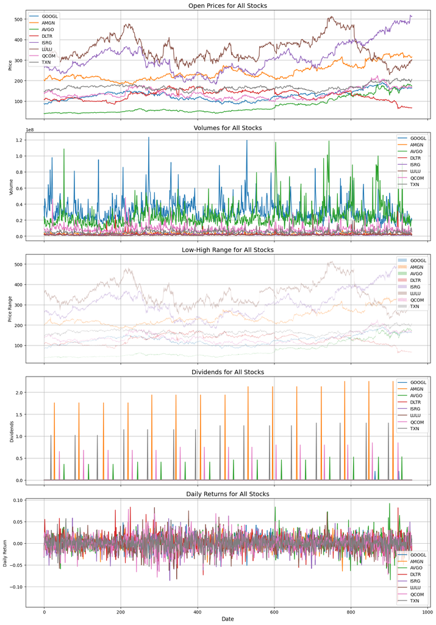

# 2. Efficient Portfolios Analysis

In this section, we analyze and estimate the set of efficient portfolios using historical data up to October 24, 2022 (end of business day). We will construct the efficient frontier without the risk-free rate ($r_f$), and subsequently calculate and plot both the Capital Market Line (CML) and Security Market Line (SML).

## 2.1. Efficient Frontier Estimation

We begin by computing the efficient frontier using our historical dataset. The process involves estimating two key parameters for each stock $i$:

- Expected returns ($\mu_i$)
- Variance-covariance matrix ($\Sigma$)

For portfolio calculations, we use the following formulas:

Portfolio expected return: $$\mu_p = \sum_{i=1}^{n} w_i\mu_i \cdot \sqrt{252}$$ Portfolio standard deviation: $$\sigma_p = \sqrt{w^T\Sigma w \cdot 252}$$

where:

- $w_i$ represents the weight of asset $i$
- $n$ is the number of trading days in one period (252)
- $\sum_{i=1}^{n} w_i = 1$ (weight property)
- $w_i \geq 0$ (no short-selling constraint)

To visualize the possible portfolio set, we simulate 100,000 portfolios with randomly generated weights (normalized to sum to 1). The resulting scatter plot in the mean-std plane ($\mu$-$\sigma$) reveals a characteristic cloud of feasible portfolios. The upper boundary of this cloud forms the efficient frontier, representing portfolios that offer the highest expected return for a given level of risk.

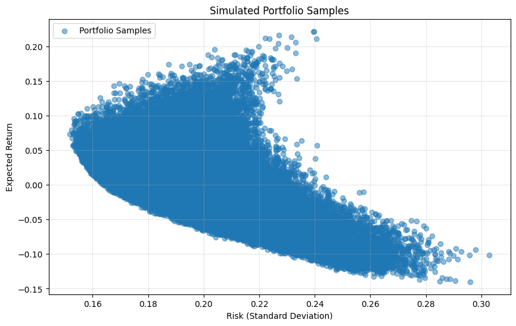

## 2.2. Efficient Frontier and Capital Market Line

First, we subsetted the risk-free rate $r_f$ and combined returns $Y$ for given period and determined the minimum variance portfolio by minimizing the portfolio variance ($\sigma_p^2 = w^T\Sigma w$), subject to constraints that portfolio weights must sum to one ($\sum_{i=1}^n w_i = 1$). This provides us with the lowest possible risk portfolio space of feasible choices.

For clarity we opted for plotting under condition of short-selling is not allowed ($w_i \geq 0$). In the numerical comparison we allowed short-selling ($w_i \in R $).

For each portfolio along our frontier, we compute the Sharpe ratio ($sr = \frac{\mu_p - r_f}{\sigma_p}$), which measures the risk-adjusted excess return. This ratio serves as a key metric in identifying the optimal risk-return trade-off and helps us locate the tangency portfolio. The efficient frontier itself is constructed through an iterative optimization process, where we minimize portfolio risk for a series of target returns while maintaining our investment constraints.

The Capital Market Line (CML) emerges from this analysis, represented by the equation $\sigma_t (\mu_{CML} - r_f) =(\mu_t - r_f)\sigma_p$. Here $\mu_t$ and $\sigma_t$ correspond to the return and risk of the tangency portfolio, respectively. This portfolio, which maximizes the Sharpe ratio, represents the optimal risk portfolio when combined with the risk-free asset. Our computational approach identifies this point by iterating through expected returns ranging from the minimum to maximum annual returns in our dataset, mapping out the complete efficient frontier and identifying the tangency point.

In the figure below, we have presented the Efficient Frontier (EF) together with the Capital Market Line (CML), which confirms our earlier analysis of the portfolio distribution. The efficient frontier, depicted as the solid blue line, traces the upper boundary of our simulated portfolio cloud. It represents the set of portfolios that offer the optimal risk-return tradeoff in the absence of a risk-free asset. This alignment with our preliminary analysis serves to validate the computational approach employed.

The plot reveals several key insights regarding our investment space:

Individual stocks, marked by black X's, generally lie below the efficient frontier, emphasizing the benefits of diversification. Portfolios on the efficient frontier consistently offer better expected returns for given levels of risk compared to individual stocks. The color gradient of the portfolio cloud, representing Sharpe ratios, further enhances the analysis. Brighter colors indicate superior risk-adjusted returns, providing additional insight into the performance of various portfolio combinations.

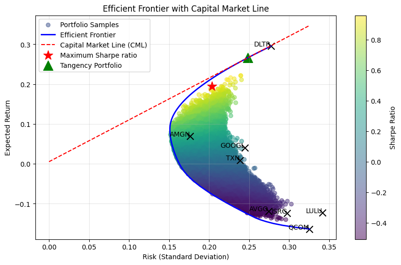

In the table below, we observe that our **tangency portfolio without short selling** is composed of only two stocks: **AMGN (13%)** and **DLTR (87%)**. This portfolio maximizes returns during this time period but is highly volatile due to the heavy concentration in **DLTR** stock. This concentration introduces significant risk, as any large fluctuation in **DLTR** can dramatically impact the portfolio's performance. We will discuss this further in the final section.

```
Tangency Portfolio Weights:
+----+----------+--------------------+----------------------+
|    | Ticker   |   No Short Selling |   With Short Selling |
|----+----------+--------------------+----------------------|
|  0 | GOOGL    |              0.000 |                0.871 |
|  1 | AMGN     |              0.130 |                0.262 |
|  2 | AVGO     |              0.000 |               -0.687 |
|  3 | DLTR     |              0.870 |                1.000 |
|  4 | ISRG     |              0.000 |               -0.383 |
|  5 | LULU     |              0.000 |               -0.336 |
|  6 | QCOM     |              0.000 |               -0.683 |
|  7 | TXN      |              0.000 |                0.955 |
+----+----------+--------------------+----------------------+
```

```
Tangency Portfolio Details:
+----+----------+--------------------+----------------------+
|    | Metric   |   No Short Selling |   With Short Selling |
|----+----------+--------------------+----------------------|
|  0 | Return   |              0.266 |                0.639 |
|  1 | Risk     |              0.248 |                0.369 |
+----+----------+--------------------+----------------------+
```

For an investor with a **reasonable level of risk-aversion**, the portfolio with short selling may be a more attractive choice. The increased risk is offset by the higher returns, and the diversification benefits from the short positions can help manage the overall portfolio risk. Therefore, investors willing to tolerate a bit more volatility in exchange for potentially higher returns might find the portfolio with short selling to be a more optimal option.

## 2.3. Security Market Line

Mathematically, the relationship between an asset's expected return and the return of the **tangency portfolio** can be described as $\mu_k - \mu_0 = \frac{\sigma_{k,T}}{\sigma_T^2} (\mu_T - \mu_0), \quad k = 1, \dots, K$.

where:

- $\mu_k$ is the expected return of asset $k$,
- $\mu_0$ is the risk-free rate,
- $\mu_T$ is the expected return of the tangency portfolio,
- $\sigma_{k,T}$ is the covariance between the returns of asset $k$ and the tangency portfolio,
- $\sigma_T^2$ is the variance of the tangency portfolio’s returns.

Rewriting this equation in terms of beta $\beta_k = \frac{\sigma_{k,T}}{\sigma_T^2}$. We estimated $\beta_k$ using theory from practicals.

This ratio, $\beta_k$, represents the asset's **beta**, which measures the asset's **systematic risk** in relation to the tangency portfolio. The **SML** illustrates how the expected return of individual assets is related to their systematic risk. The higher the beta, the higher the expected return, assuming a linear relationship.

### 2.3.1 Interpretation of SML

In our graph, the **Security Market Line (SML)** is represented by the blue line, which starts at the risk-free rate and slopes upward. The line illustrates the positive linear relationship between **beta** and **expected return**. The individual stocks in our portfolio are plotted according to their respective betas (x-axis) and expected returns (y-axis). The positioning of these stocks relative to the SML provides valuable insights:

In general, most stocks appear to be **overpriced**, as they are positioned below the SML, indicating that their expected returns do not adequately compensate for their level of risk. This underperformance suggests that, based on the CAPM model, investors might be taking on more risk than is justified by the returns.

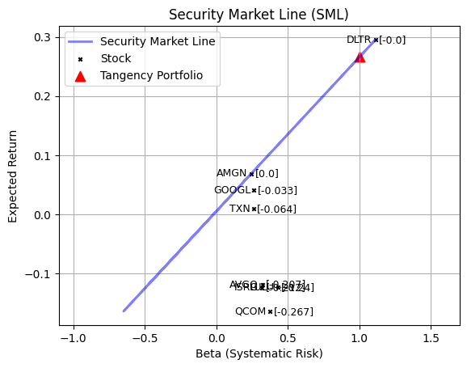

# 3. Markowitz Model

### 3.1 Theoretical Background

The **Markowitz model** (Mean-Variance Optimization) aims to find the optimal portfolio that balances risk and return. The model defines the optimal portfolio weights $w$ that either maximize expected return subject to a constraint on portfolio risk or minimize portfolio risk for a given expected return. We opted for the second option, thus our optimization problem is formulated as follows:

$$ \min_w \quad \frac{1}{2} w^T \Sigma w $$ subject to: $$ w^T \mu + w_0 r_f \geq \bar{\mu} $$ $$ w^T \mathbf{1} + w_0 = 1 $$

where:

- $w$ is the vector of portfolio weights.
- $\Sigma$ is the covariance matrix of asset returns.
- $\mu$ is the vector of expected asset returns.
- $r_f$ is the risk-free rate.
- $w_0$ is the weight assigned to the risk-free asset.
- $\bar{\mu}$ is the minimum required portfolio return.
- $\mathbf{1}$ is a vector of ones.

The minimum expected return $\bar{\mu}$ of **10% p.a.** is chosen as a realistic target based on current market behavior and risk tolerance. We have chosen historical returns and variance as our estimates, since they yielded best results against other ones (e.g. Exponentially Weighted Moving Average).

The **expected returns** $\hat{\mu}_i$ for each asset are estimated using historical data as the sample mean of asset returns over a chosen period: $$ \hat{\mu}_i = \frac{1}{T} \sum_{t=1}^{T} \mu_{i,t} $$ where $\mu_{i,t}$ represents the return of asset $i$ at time $t$, and $T$ is the number of historical data points.

The **variance-covariance matrix** $\Sigma$ is estimated as: $$ \hat{\Sigma}_{i,j} = \frac{1}{T-1} \sum_{t=1}^{T} (\mu_{i,t} - \hat{\mu}_i)(\mu_{j,t} - \hat{\mu}_j) $$ where $\hat{\Sigma}_{i,j}$ represents the covariance between the returns of assets $i$ and $j$.

## 3.2. Visualization of Markowitz Portfolio

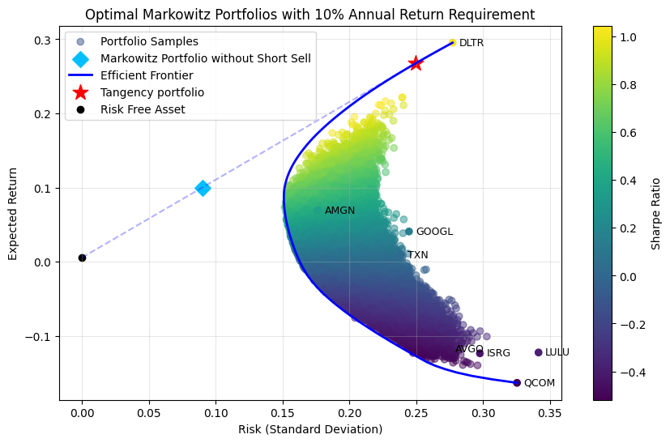

For clarity, we again decide to showcase only the no short-selling allowed option ($w_i \geq 0$). The Markowitz Portfolio is located on the Capital Market Line (CML), confirming the correctness of our computation. This illustrates a key insight: by incorporating a risk-free asset, we can achieve a portfolio with similar expected returns to the minimum variance portfolio without $r_f$, but with a significantly lower level of risk.

Additionally, the Tangency Portfolio (marked with a red star) represents the point on the Efficient Frontier that maximizes the Sharpe Ratio. By mixing this portfolio with the risk-free asset, we construct the CML, which dominates all other efficient portfolios in terms of risk-adjusted return. The blue diamond highlights the Markowitz Portfolio without short-selling, which meets the imposed 10% minimum expected return requirement while adhering to the no-short-selling constraint.

The Sharpe Ratio heatmap further emphasizes that portfolios along the CML generally have higher risk-adjusted returns compared to those located purely on the Efficient Frontier.

### 2.3 Interpretation of Markowitz Portfolio

The tables below present the portfolio weights for two scenarios: **short selling not allowed** and **short selling allowed**.

In the **no short-selling** case, our **optimal portfolio** continues to have only **two non-zero weights**, consistent with our findings in Section 2. However, a significant portion (over **60%**) of the portfolio is now allocated to the **risk-free asset**, indicating a conservative strategy that prioritizes minimum risk over large returns. This allocation allows us to achieve the target **10% expected return**, but with a slightly higher risk of **9%** due to the reliance on fewer assets.

When **short selling is permitted**, the portfolio composition shifts to resemble the **Tangency Portfolio**, but with the addition of the **risk-free asset**. This adjustment allows us to **achieve the same 10% expected return while reducing portfolio risk to just 5.5%**. The ability to take short positions provides greater flexibility, leading to improved risk-adjusted performance.

Comparing both scenarios:

- When **short selling is allowed**, the portfolio achieves the target return with **5.5% standard deviation**, benefiting from leveraged exposure and diversification.
- When **short selling is not allowed**, the portfolio relies heavily on the risk-free asset, maintaining a **10% return but with a slightly higher risk of 9%**.

These results highlight the impact of short selling and risk-free asset allocation in constructing an efficient portfolio, balancing return objectives with different levels of risk exposure.

```
 Portfolio Performance Metrics:
+----+------------------------+-------------------------------+--------------+
|    | Metric                 |   Short Positions Not Allowed |   SP Allowed |
|----+------------------------+-------------------------------+--------------|
|  0 | Risk-free Asset Weight |                         0.637 |        0.865 |
|  1 | Expected Yearly Return |                         0.1   |        0.1   |
|  2 | Portfolio Risk         |                         0.09  |        0.055 |
+----+------------------------+-------------------------------+--------------+

 Portfolio Weights Comparison:
+----+----------+------------------+--------------+
|    | Ticker   |   SP Not Allowed |   SP Allowed |
|----+----------+------------------+--------------|
|  0 | GOOGL    |            0     |        0.138 |
|  1 | AMGN     |            0.047 |        0.027 |
|  2 | AVGO     |            0     |       -0.095 |
|  3 | DLTR     |            0.316 |        0.151 |
|  4 | ISRG     |            0     |       -0.057 |
|  5 | LULU     |            0     |       -0.053 |
|  6 | QCOM     |            0     |       -0.105 |
|  7 | TXN      |            0     |        0.128 |
+----+----------+------------------+--------------+
```

# 4. Out-Of-Sample Investing

In this section, we implement the proposed **dynamic investment strategy**, where the **portfolio is rebalanced daily** based on the most recent market data. The strategy begins on **October 25, 2022**, and continues until **October 24, 2024**. Each day, we update our **optimal portfolio allocation** using only the information available **up to the previous trading day**, ensuring that no future data influences the decisions.

We analyze the **performance of this dynamic strategy**, comparing its **realized returns** against the **expected return** derived from our initial assumptions and parameter selection. Additionally, we benchmark its performance against:

1. A **equal-weighted portfolio**, where all stocks receive an equal share of the investment.
2. A **fixed tangency portfolio**, as identified in Section 2, which does not adjust for daily market movements.

By evaluating the **cumulative return, risk-adjusted performance, and volatility** of each approach, we gain insights into the **effectiveness of dynamic rebalancing** and its advantages over static investment strategies. No short-selling was allowed.

## 4.1 Portfolio Performance Comparison

The figure below presents a comparison of all three portfolio strategies: **Markowitz Portfolio**, **Equal Weights Portfolio**, and **Tangency Portfolio**.

One key observation is that the **Equal Weights Portfolio** and **Tangency Portfolio** exhibit a similar directional movement, which is expected. However, the **Tangency Portfolio** suffered from a major issue we were cautious about—its heavy reliance on **DLTR stock**. While **DLTR** performed exceptionally well in the **training set**, it performed **poorly in the test set** (as seen in Section 1). This explains the two major downward trends in its performance, which align with our earlier analysis.

On the other hand, the **Markowitz Portfolio** initially experienced a **slight downward trend**, but over time, it demonstrated a **gradual upward movement**. While the growth is not significant, it aligns with our earlier commentary: **low volatility but also relatively low returns**. This suggests that the **Markowitz Portfolio** provided a more stable investment approach compared to the other two strategies.

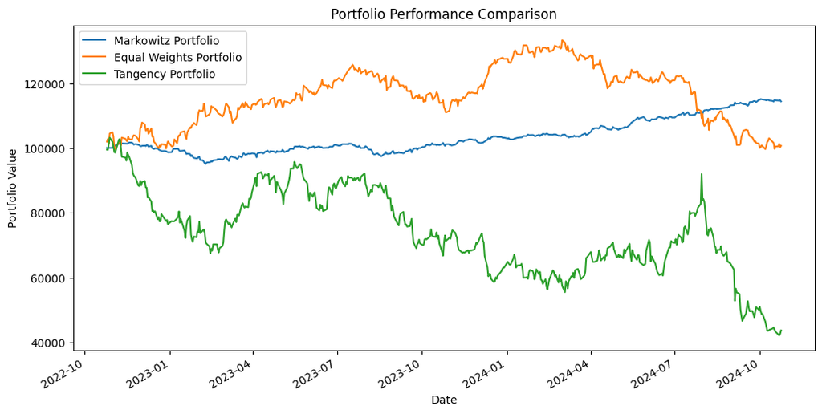

## 4.2 Portfolio Performance Comparison with S&P 500

The **S&P 500** index is a widely recognized benchmark in the investment world. To better assess our portfolio's performance, we introduced the S&P 500 as a comparison. Notably, every stock in our portfolio is part of the **S&P 500** index.

According to [Wall Street Numbers](https://wallstreetnumbers.com/screeners/sp500), **GOOGL** is the sixth-largest company by market capitalization, making it the most influential stock from our portfolio in the index. Estimates suggest it holds a weight of approximately **2.1%** in the S&P 500, as reported by [WikiJob](https://www.wikijob.co.uk/trading/stocks/stocks-by-index-weight#top-10-sp-500-stocks-by-index-weight-2025) and [Investopedia](https://www.investopedia.com/top-25-stocks-in-the-s-and-p-500-september-2023-7853313#toc-top-25-sp-500-companies-by-market-cap). The second-largest stock from our portfolio, **AVGO**, has a weight of around **0.97%**. Given that these stocks represent only a small fraction of the index, we can reasonably assume that our portfolio behaves as a **semi-independent entity** rather than directly mirroring the S&P 500's movements.

To analyze the S&P 500 alongside our portfolio, we imported the index data for the same period and computed the daily log returns. The figure below shows the **closing prices** (`Close`) and the corresponding **daily log returns** (`Daily`) of the S&P 500 index.

From the plot, we observe that the index exhibits a general **upward trend**, with only a few short-lived declines. Furthermore, in terms of **daily log returns**, volatility appears to have **decreased towards the end of the period**, although we still see occasional negative spikes.

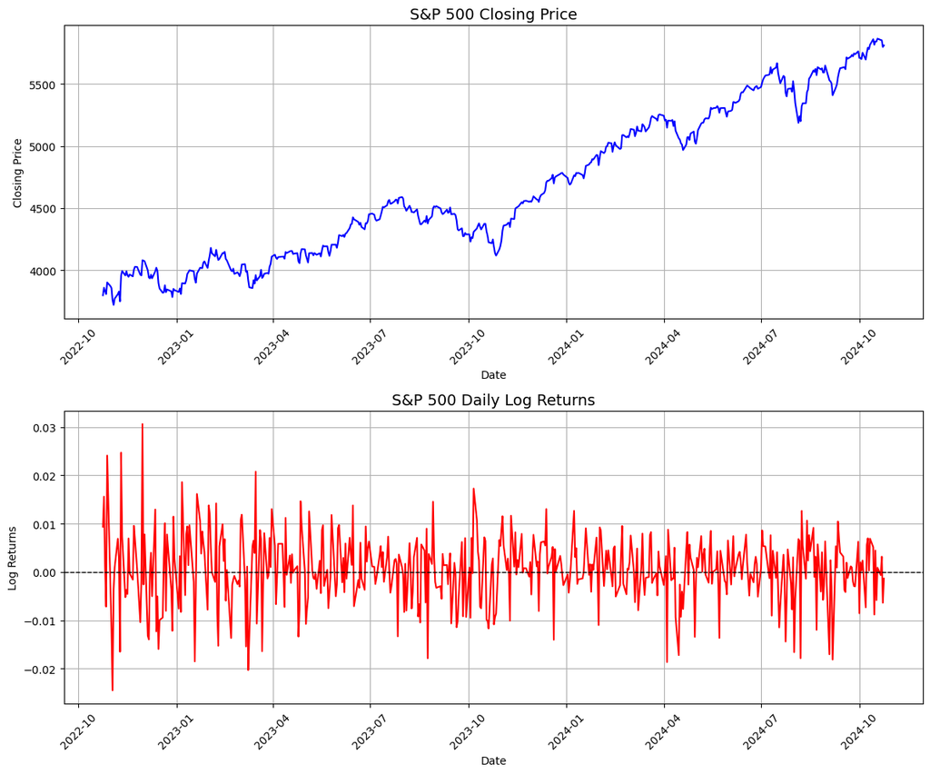

We normalized the **S&P 500** index to facilitate a better comparison with our portfolio's performance. In the plot below, we visualize the trajectory of the normalized **S&P 500** alongside the performance of our **equal-weighted portfolio**.

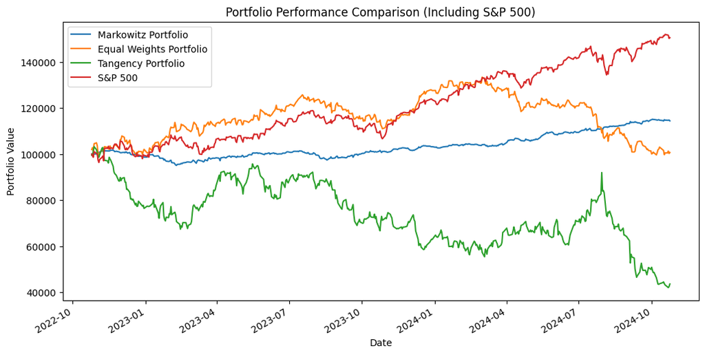

[output not shown]

```
Worst Loss for Each Portfolio:
+-------------------------+--------------+-------------+---------------+
| Portfolio               | Worst Loss   | Peak Date   | Trough Date   |
|-------------------------+--------------+-------------+---------------|
| Markowitz Portfolio     | 6.52%        | 2022-11-08  | 2023-02-09    |
| Equal Weights Portfolio | 25.27%       | 2024-03-01  | 2024-10-07    |
| Tangency Portfolio      | 59.22%       | 2022-10-28  | 2024-10-22    |
| S&P 500                 | 10.28%       | 2023-07-31  | 2023-10-27    |
+-------------------------+--------------+-------------+---------------+
```

The **Tangency Portfolio** has the worst loss of **59.22%**, which, if we had invested initially, would have cost us more than **60,000** in losses alone, not factoring in the potential opportunity cost of missing better investment opportunities. This significant loss suggests that the **Tangency Portfolio** is highly volatile and risky. The **Equal Weights Portfolio** also shows a considerable loss of **25.27%**, which, while lower, still represents a significant decline in value. The **Markowitz Portfolio**, on the other hand, offers the smallest worst loss of **6.52%**, indicating it is the least risky among the strategies.

In conclusion, the **Tangency Portfolio** presents the most substantial risk, with a large potential loss, while the **Markowitz Portfolio** seems the most prudent choice in terms of minimizing losses. The **Equal Weights Portfolio** falls in between, showing that its risk is high with little reward. The losses observed in these portfolios further emphasize the importance of risk management and strategic diversification in portfolio selection.

# Conclusion

In the second section, we **simulated the efficient frontier**, excluding the risk-free rate and disallowing short sales. We then computed the **Sharpe ratio**, which led us to derive the **Capital Market Line (CML** and **Security Market Line (SML)** and identify the **Tangency Portfolio**, which consisted of only two tickers.

The third section focused on **portfolio optimization with variance minimization**, subject to a **minimum return constraint of 10%**. We computed **optimal portfolio weights** under two scenarios:

- **No short selling:** The portfolio relied heavily on the **risk-free asset**, leading to a **9% standard deviation**, while still maintaining the **target 10% return**.
- **Short selling allowed:** The portfolio structure resembled the **Tangency Portfolio**, but with added exposure to the **risk-free asset**. This resulted in a **lower standard deviation of 5.5%**, making it a highly efficient choice for minimizing risk at the given return level.

Finally, in the last section, we assessed our strategy by comparing four models:

1. **Equal-weighted portfolio**
2. **Tangency Portfolio**
3. **Markowitz Portfolio**
4. **S&P 500 Index**

While the **Markowitz Portfolio** was profitable, it achieved only **mid-range expected returns**. The **S&P 500** remained the **best-performing strategy**, benefiting from its well-diversified structure. However, we noted that **raising the minimum return constraint** could potentially **improve expected results**, albeit at the cost of **higher risk**.